# Donor based Imputation Methods

Wolfgang Rannetbauer

## Overview

In addition to Model based Imputation Methods (see `vignette("modelImp")`) the `VIM` package also presents donor based imputation methods, namely Hot-Deck Imputation, k-Nearest Neighbour Imputation and fast matching/imputation based on categorical variable.

This vignette showcases the functions `hotdeck()` and `kNN()`, which can both be used to generate imputations for several variables in a dataset. Moreover, the function `matchImpute()` is presented, which is in contrast a imputation method based on categorical variables.

## Data

The following example demonstrates the functionality of `hodeck()` and `kNN()` using a subset of `sleep`. The columns have been selected deliberately to include some interactions between the missing values.

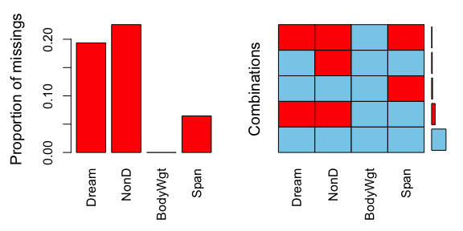

```r
library(VIM)
dataset <- sleep[, c("Dream", "NonD", "BodyWgt", "Span")]
dataset$BodyWgt <- log(dataset$BodyWgt)
dataset$Span <- log(dataset$Span)
aggr(dataset)
```

The plot indicates several missing values in `Dream`, `NonD`, and `Span.`

```r
sapply(dataset, function(x)sum(is.na(x)))
```

```
#>   Dream    NonD BodyWgt    Span
#>      12      14       0       4
```

## Imputation

The call of the functions is straightforward. We will start by just imputing `NonD` based on the other variables. Besides imputing missing variables for a single variable, these functions also support imputation of multiple variables. For `matchImpute()` suitable donors are searched based on matching of the categorical variables.

```r
imp_hotdeck <- hotdeck(dataset, variable = "NonD")  # hotdeck imputation
imp_knn <- kNN(dataset, variable = "NonD") # kNN imputation
```

```
#>      Dream    BodyWgt       Span      Dream    BodyWgt       Span
#>  0.0000000 -5.2983174  0.6931472  6.6000000  8.8029735  4.6051702
```

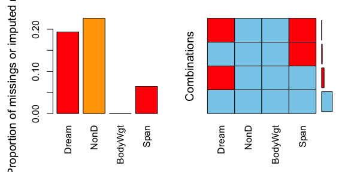

```r
imp_match <- matchImpute(dataset, variable = "NonD", match_var = c("BodyWgt","Span")) # match imputation
aggr(imp_knn, delimiter = "_imp")
aggr(imp_match, delimiter = "_imp")
```

We can see that `kNN()` imputed all missing values for `NonD` in our dataset. The same is true for the values imputed via `hotdeck()`. The specified variables in `matchImpute()` serve as a donor and enable imputation for `NonD`.

### Diagnosing the results

As we can see in the next two plots, the origninal data structure of `NonD` and `Span` is preserved by `hotdeck()`. `kNN()` reveals the typically procedure of methods, which are based on similar data points weighted by the distance.

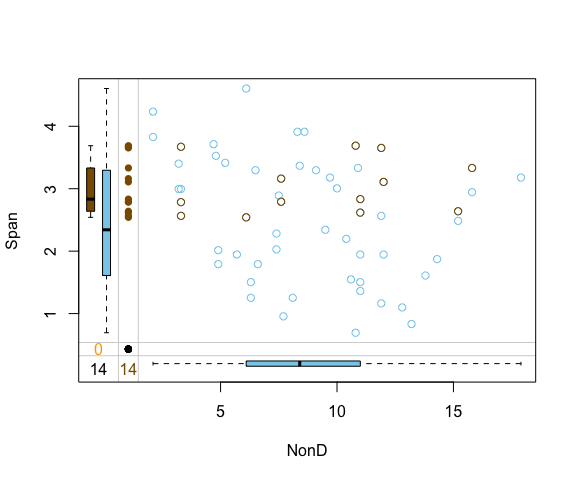

```r
imp_hotdeck[, c("NonD", "Span", "NonD_imp")] |>
  marginplot(delimiter = "_imp")
```

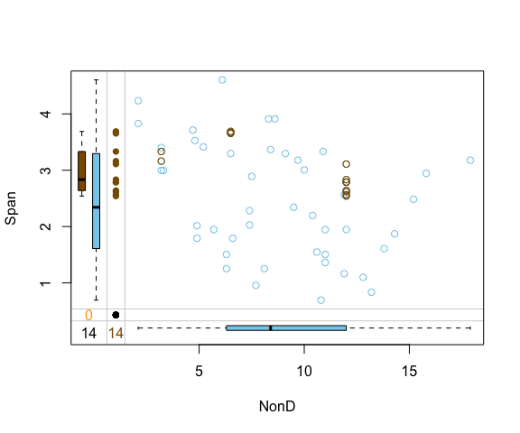

```r
imp_knn[, c("NonD", "Span", "NonD_imp")] |>
  marginplot(delimiter = "_imp")
```

`matchImpute()` works by sampling values from the suitable donors and also provides reasonable results.

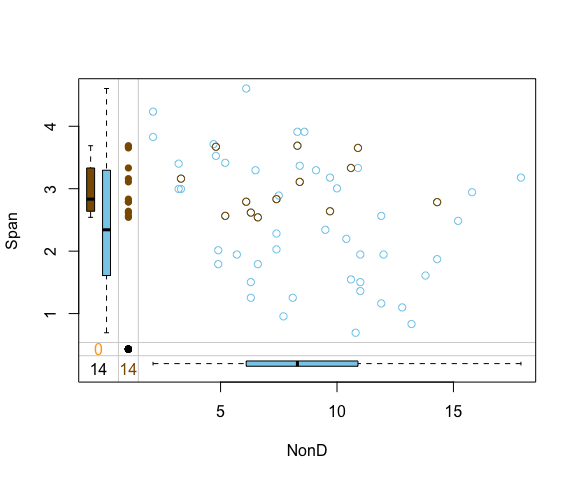

```r
imp_match[, c("NonD", "Span", "NonD_imp")] |>
  marginplot(delimiter = "_imp")
```

## Performance of method

In order to validate the performance of `kNN()` and to highlight the ability to impute different datatypes the `iris` dataset is used. Firstly, some values are randomly set to `NA`.

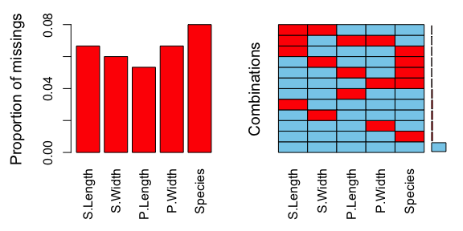

```r
data(iris)
df <- iris
colnames(df) <- c("S.Length","S.Width","P.Length","P.Width","Species")
# randomly produce some missing values in the data
set.seed(1)
nbr_missing <- 50
y <- data.frame(row = sample(nrow(iris), size = nbr_missing, replace = TRUE),
                col = sample(ncol(iris), size = nbr_missing, replace = TRUE))
y<-y[!duplicated(y), ]
df[as.matrix(y)] <- NA

aggr(df)
```

```r
sapply(df, function(x) sum(is.na(x)))
```

```
#> S.Length  S.Width P.Length  P.Width  Species
#>       10        9        8       10       12
```

We can see that there are missings in all variables and some observations reveal missing values on several points.

```r
imp_knn <- kNN(df)
```

```
#>  S.Width P.Length  P.Width  S.Width P.Length  P.Width
#>      2.0      1.0      0.1      4.4      6.9      2.5
#> S.Length P.Length  P.Width S.Length P.Length  P.Width
#>      4.3      1.0      0.1      7.9      6.9      2.5
#> S.Length  S.Width  P.Width S.Length  S.Width  P.Width
#>      4.3      2.0      0.1      7.9      4.4      2.5
#> S.Length  S.Width P.Length S.Length  S.Width P.Length
#>      4.3      2.0      1.0      7.9      4.4      6.9
#> S.Length  S.Width P.Length  P.Width S.Length  S.Width P.Length  P.Width
#>      4.3      2.0      1.0      0.1      7.9      4.4      6.9      2.5
```

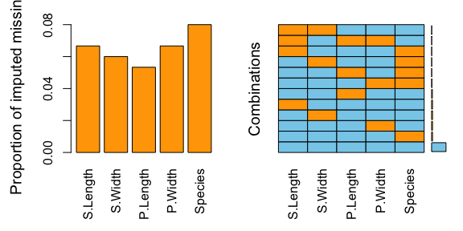

```r
aggr(imp_knn, delimiter = "imp")
```

The plot indicates that all missing values have been imputed by `kNN()`. The following table displays the rounded first five results of the imputation for all variables.

| True | Imputed | True | Imputed | True | Imputed | True | Imputed | True | Imputed |
| --- | --- | --- | --- | --- | --- | --- | --- | --- | --- |
| 6.4 | 6.9 | 4.1 | 3.5 | 4.1 | 4 | 0.2 | 0.2 | setosa | setosa |
| 7 | 6.4 | 2.7 | 3.2 | 4.1 | 4.2 | 0.2 | 0.4 | virginica | virginica |
| 5.4 | 6.1 | 2.8 | 2.8 | 3.9 | 4.5 | 0.3 | 0.2 | versicolor | versicolor |
| 6.5 | 6.8 | 3.8 | 3.5 | 5.1 | 5.5 | 1.5 | 1.4 | versicolor | virginica |
| 7.6 | 6.3 | 3.5 | 3.4 | 4.7 | 4.5 | 0.2 | 0.2 | virginica | virginica |